# Gentle introduction to Linear Regression

Katarzyna Sornat

8 11 2020

## Linear regression

Linear regression is used for finding linear relationship between target and one or more predictors. There are two types of linear regression- Simple (one explanatory variable/predictor/independent variable) and Multiple (more predictors).

### Secret smoothies

Smoothie recipe

- 1 cup plain yogurt
- 1 secret ingredient
- random food dyes

Blend ingredients. Serve.

### Predict calories

What’s inside?

- 1 cup plain yogurt
- 1 secret ingredient
- random food dyes

### Sardine smoothie!

What’s inside?

- 1 cup plain yogurt
- 58 g sardines in tomato sauce
- random food dyes

233 Calories

### Predict calories

What’s inside?

- 1 cup plain yogurt
- 1 secret ingredient
- random food dyes

### Waffle mix smoothie!

What’s inside?

- 1 cup plain yogurt
- 56 g waffle mix
- random food dyes

301 Calories

### Predict calories

What’s inside?

- 1 cup plain yogurt
- 1 secret ingredient
- random food dyes

### Predict the calories

Can we use something?

### Predict the calories

Calories of 15 of our smoothies:

713, 288, 268, 252, 306, 301, 233, 150, 143, 416, 414, 155, 383, 258, 292

### Predict the calories

Calories of 15 of our smoothies:

mean 304.8 median 288

### Mascarpone smoothie!

What’s inside?

- 1 cup plain yogurt
- 72 g Mascarpone
- random food dyes

447 Calories

### How did we do?

Underestimate = 304.8

### Can we do better?

Underestimate = 304.8

Use weight of the secret ingredient!

### Predict the calories

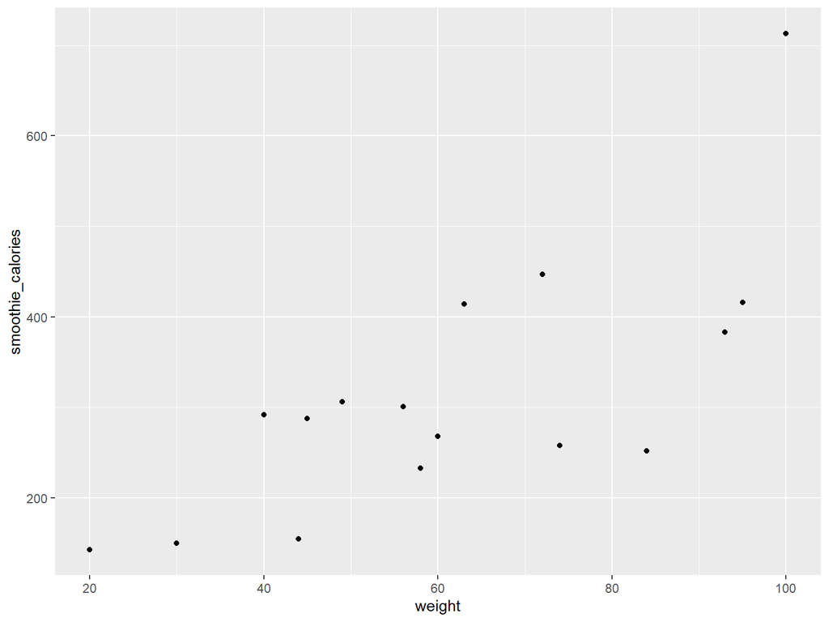

### Put A Line Through It!

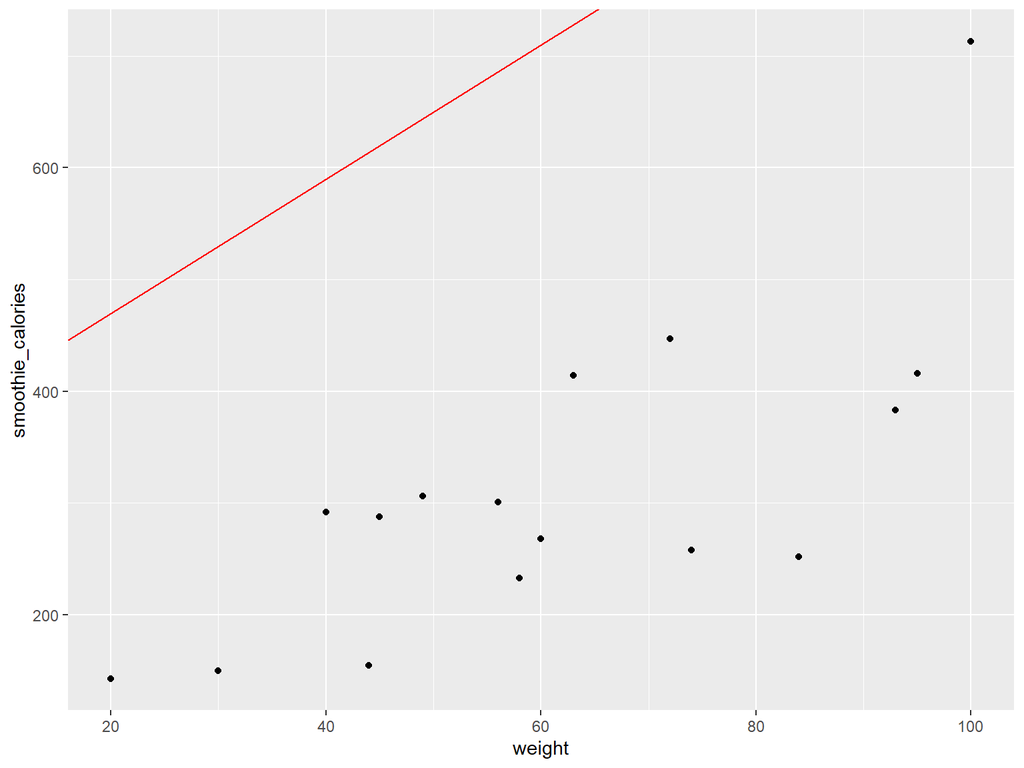

Smoothie_calories = Intercept + Slope * weight

### Put A Line Through It!

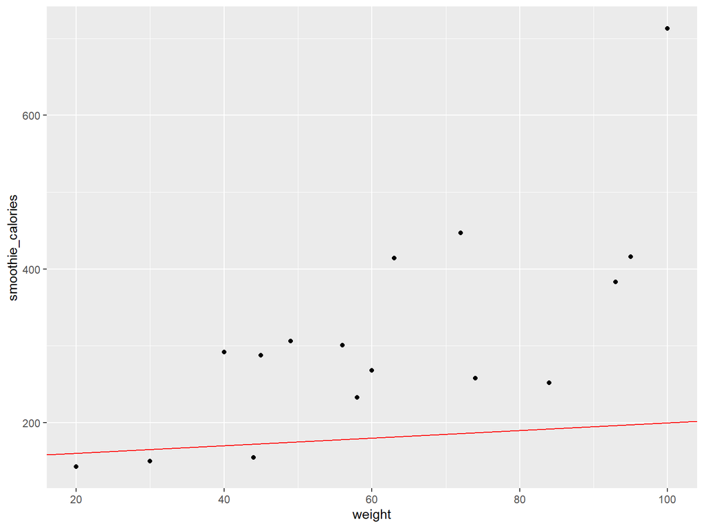

### Put A Line Through It!

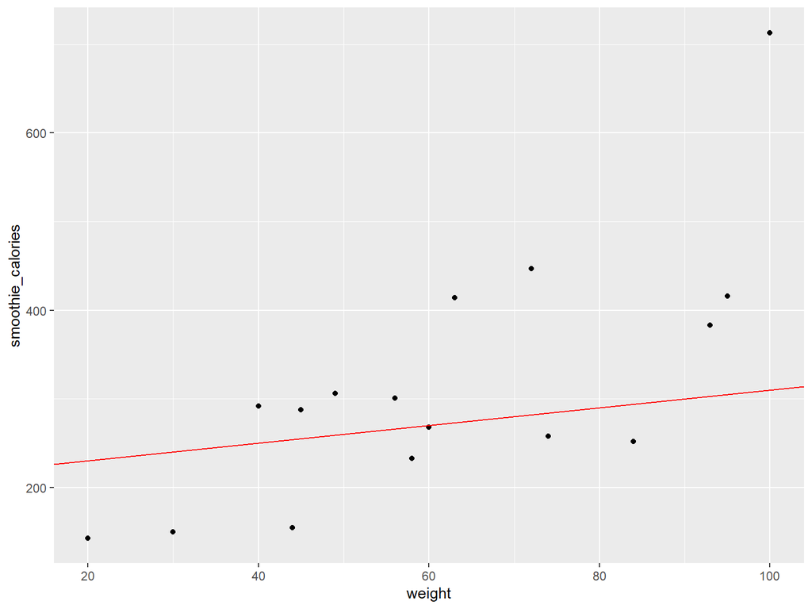